# Practical Machine Learning Course Project

Igor.Misechko

21 december 2015

## Summary

Using devices such as Jawbone Up, Nike FuelBand, and Fitbit it is now possible to collect a large amount of data about personal activity relatively inexpensively. These type of devices are part of the quantified self movement – a group of enthusiasts who take measurements about themselves regularly to improve their health, to find patterns in their behavior, or because they are tech geeks. One thing that people regularly do is quantify how much of a particular activity they do, but they rarely quantify how well they do it. In this project, your goal will be to use data from accelerometers on the belt, forearm, arm, and dumbell of 6 participants. They were asked to perform barbell lifts correctly and incorrectly in 5 different ways.  
The goal of our project is to predict the manner in which they did the exercise. This is the “classe” variable in the training set.

## Load used packages

```r
packages <- c("ggplot2", "caret", "data.table", "dplyr", "randomForest", "knitr", "doParallel", "dummies")
packages <- lapply(packages, FUN = function(x) {
     if (!require(x, character.only = T, quietly = T, warn.conflicts =  F)) {
          install.packages(x)
          suppressWarnings(library(x, character.only = T, quietly = T, warn.conflicts =  F, verbose = F, logical.return = F))
     }
})
```

```
## dummies-1.5.6 provided by Decision Patterns
```

## Load and read data

The anlyzing data load from:  
- Training dataset are [there](https://d396qusza40orc.cloudfront.net/predmachlearn/pml-training.csv).  
- Testing dataset are [there](https://d396qusza40orc.cloudfront.net/predmachlearn/pml-testing.csv).  
Process of collecting data in dataset described by [link there](http://groupware.les.inf.puc-rio.br/public/papers/2013.Velloso.QAR-WLE.pdf).

```r
#Training dataset
fileDest <- "pml-training.csv"
fileUrl <- "https://d396qusza40orc.cloudfront.net/predmachlearn/pml-training.csv"
download.file(fileUrl, fileDest)
pmltr <- read.table(fileDest, header = TRUE, sep = ",", dec = ".", na.strings = c("NA","#DIV/0!","(Other)"))
pmltr0 <- pmltr
#Test dataset
fileDest <- "pml-testing.csv"
fileUrl <- "https://d396qusza40orc.cloudfront.net/predmachlearn/pml-testing.csv"
download.file(fileUrl, fileDest)
test <- read.table(fileDest, header = TRUE, sep = ",", dec = ".", na.strings = c("NA","#DIV/0!","(Other)"))
```

Train dataset has dimensions: 19622, 160.

## Pre-Processing

Process of pre-processing include 4 steps:  
1) Remove non-complete cases and non-used variables  
2) Remove variables with near zero variances  
3) Check for highly corelated variables  
4) Check for linear dependencies

First we need to check for missing values (NA).

```r
anyNA(pmltr)
```

```
## [1] TRUE
```

Dataset include NA values. We need to remove variables with NA values and try to reduce number of variables.

```r
isna <- apply(pmltr, 2, anyNA)
nms <- names(pmltr0)
nms <- data.frame(cbind(nms, as.character(isna)))
nms <- filter(nms, V2 == TRUE)
pmltr0 <- select(pmltr0, -one_of(as.character(nms$nms)))
test0 <- select(test, -one_of(as.character(nms$nms)))
```

After remove non-complete variables our dataset has dimensions: 19622, 60.

Now we try to make some different dataset and build model fit with their.

```r
rmCol <- c("X",
            "raw_timestamp_part_1",
            "raw_timestamp_part_2",
            "cvtd_timestamp",
            "user_name",
            "new_window",
           "num_window")
pmltr1 <- data.table(select(pmltr0, -one_of(rmCol)))
test1 <- data.table(select(test0, -one_of(rmCol)))
```

After remove first 7 variables final dataset has dimensions: 19622, 53.  
This is **Data set #1**, that we include to analysis.

In second dataset we check for variables with near zero variances

```r
nzv <- nearZeroVar(pmltr0)
pmltr2 <- select(pmltr0, -nzv)
test2 <- select(test0, -nzv)
```

Now we check highly corelated variables

```r
descrCor <- cor(select(pmltr1, -classe), use="pairwise.complete.obs")
highlyCorDescr <- findCorrelation(descrCor, cutoff = .70)
pmltr2 <- select(pmltr2, -highlyCorDescr)
test2 <- select(test2, -highlyCorDescr)
```

After remove variables with near zero variances and highly corelated final dataset has dimensions: 19622, 37.  
This is **Data set #2**, that we include to analysis.

In third dataset we first make a dummy variables from factor variables (except ‘classe’)

```r
pmltr3 <- dummy.data.frame(pmltr0, names = c("user_name", "new_window"))
test3 <- dummy.data.frame(test0, names = c("user_name", "new_window"), omit.constants=F)
```

This dataset we check for highly corelated variables too.

```r
descrCor <- cor(select(pmltr1, -classe), use="pairwise.complete.obs")
highlyCorDescr <- findCorrelation(descrCor, cutoff = .70)
pmltr3 <- select(pmltr3, -highlyCorDescr)
test3 <- select(test3, -highlyCorDescr)
```

In last we check for Linear dependencies

```r
tt <- select(pmltr3, -classe)
comboInfo <- findLinearCombos(tt)
comboInfo$remove
```

[output not shown]

There are not variables with linear dependencies.

After make dummy variables and remove highly corelated variables final dataset has dimensions: 19622, 44.  
This is **Data set #3**, that we include to analysis.

## Split data into train and validation set

Data splitted in proportion of 75% for train data set and 25% for testing. Data splitted for each data set.

```r
set.seed(107)
inTrain <- createDataPartition(y = pmltr1$classe,
                               p = .75,
                               list = FALSE)
trn1 <- filter(pmltr1, inTrain)
vld1 <- filter(pmltr1, -inTrain)
inTrain2 <- createDataPartition(y = pmltr2$classe,
                               p = .75,
                               list = FALSE)
trn2 <- pmltr2[inTrain2,]
vld2 <- pmltr2[-inTrain2, ]

inTrain3 <- createDataPartition(y = pmltr3$classe,
                               p = .75,
                               list = FALSE)
trn3 <- pmltr3[inTrain3,]
vld3 <- pmltr3[-inTrain3, ]
```

## Biuld model fit

### Recursive Partitioning (Predicting with trees)

Building model fit with Data set #1

```r
rpartFit1 <- train(classe ~ .,method="rpart",data=trn1)
rpCM1 <- confusionMatrix(vld1$classe,predict(rpartFit1,vld1))
rpCM1$overall[1]
```

```
##  Accuracy
## 0.4955139
```

Building model fit with Data set #2

```r
rpartFit2 <- train(classe ~ .,method="rpart",data=trn2)
rpCM2 <- confusionMatrix(vld2$classe,predict(rpartFit2,vld2))
rpCM2$overall[1]
```

```
##  Accuracy
## 0.4802202
```

Building model fit with Data set #3

```r
rpartFit3 <- train(classe ~ .,method="rpart",data=trn3)
rpCM3 <- confusionMatrix(vld3$classe,predict(rpartFit3,vld3))
rpCM3$overall[1]
```

```
## Accuracy
## 0.495106
```

### Boosting algorithm (GBM - boosting with trees)

Building model fit with Data set #1

```r
set.seed(825)
cl <- makeCluster(detectCores()/2)
registerDoParallel(cl)
gbmFit1 <- train(classe ~ ., data = trn1,
                 method = "gbm",
                 trControl=trainControl(method = "cv", number = 4),
                 verbose = FALSE)
stopCluster(cl)
gbmPred1 <- predict(gbmFit1,newdata=vld1)
gbmCM1 <- confusionMatrix(vld1$classe,predict(gbmFit1,vld1))
gbmCM1$overall[1]
```

```
##  Accuracy
## 0.9641109
```

Building model fit with Data set #2

```r
set.seed(825)
cl <- makeCluster(detectCores()/2)
registerDoParallel(cl)
gbmFit2 <- train(classe ~ ., data = trn2,
                 method = "gbm",
                 trControl=trainControl(method = "cv", number = 4),
                 verbose = FALSE)
stopCluster(cl)
gbmPred2 <- predict(gbmFit2,newdata=vld2)
gbmCM2 <- confusionMatrix(vld2$classe,predict(gbmFit2,vld2))
gbmCM2$overall[1]
```

```
##  Accuracy
## 0.9946982
```

Building model fit with Data set #3

```r
set.seed(825)
cl <- makeCluster(detectCores()/2)
registerDoParallel(cl)
gbmFit3 <- train(classe ~ ., data = trn3,
                 method = "gbm",
                 trControl=trainControl(method = "cv", number = 4),
                 verbose = FALSE)
stopCluster(cl)
gbmPred3 <- predict(gbmFit3,newdata=vld3)
gbmCM3 <- confusionMatrix(vld3$classe,predict(gbmFit3,vld3))
gbmCM3$overall[1]
```

```
##  Accuracy
## 0.9669657
```

### Random Forests algorithm

Building model fit with Data set #1

```r
cl <- makeCluster(detectCores()/2)
 registerDoParallel(cl)
suppressWarnings(rfFit1 <- train(classe ~ .,data = trn1,method="rf", preProcess=c("center", "scale"), trControl=trainControl(method = "cv", number = 4)))
stopCluster(cl)
rfCM1 <- confusionMatrix(vld1$classe,predict(rfFit1,vld1))
rfCM1$overall[1]
```

```
##  Accuracy
## 0.9916395
```

Building model fit with Data set #2

```r
cl <- makeCluster(detectCores()/2)
registerDoParallel(cl)
set.seed(71)
suppressWarnings(rfFit2 <- train(classe ~ .,data = trn2,method="rf", preProcess=c("BoxCox","center", "scale"), trControl=trainControl(method = "cv", number = 4)))

stopCluster(cl)
rfPred2 <- predict(rfFit2,vld2)
rfCM2 <- confusionMatrix(vld2$classe,predict(rfFit2,vld2))
rfCM2$overall[1]
```

```
## Accuracy
## 0.997553
```

Building model fit with Data set #3

```r
cl <- makeCluster(detectCores()/2)
registerDoParallel(cl)
suppressWarnings(rfFit3 <- train(classe ~ .,data = trn3,method="rf", preProcess=c("BoxCox","center", "scale"), trControl=trainControl(method = "cv", number = 4)))
stopCluster(cl)
rfCM3 <- confusionMatrix(vld3$classe,predict(rfFit3,vld3))
rfCM3$overall[1]
```

```
##  Accuracy
## 0.9961256
```

## Comparing results and plotting

In table below include results for 3 methods in tree dataset.

```r
Rpart <- c(rpCM1$overall[1],rpCM2$overall[1],rpCM3$overall[1])
GBM <- c(gbmCM1$overall[1],gbmCM2$overall[1],gbmCM3$overall[1])
Random.Forests <- c(rfCM1$overall[1],rfCM2$overall[1],rfCM3$overall[1])
m2 <- (rbind(Rpart,GBM,Random.Forests))
colnames(m2) <- c("Data set #1", "Data set #2", "Data set #3")
kable(m2)
```

|  | Data set #1 | Data set #2 | Data set #3 |
| --- | --- | --- | --- |
| Rpart | 0.4955139 | 0.4802202 | 0.4951060 |
| GBM | 0.9641109 | 0.9946982 | 0.9669657 |
| Random.Forests | 0.9916395 | 0.9975530 | 0.9961256 |

As we can see the best Accuracy is for Random forests with **Data set #2** (removing variables with near zero variances and highly corelated).

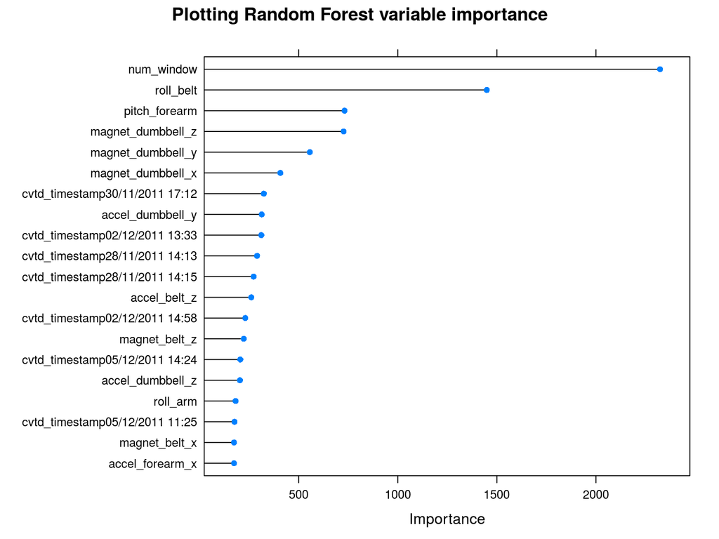

```r
rfImp <- varImp(rfFit2, scale = FALSE)
p2 <- plot(rfImp, top = 20,  main = "Plotting Random Forest variable importance")
p2
```

```r
StatChull <- ggproto("StatChull", Stat,
  compute_group = function(data, scales) {
    data[chull(data$x, data$y), , drop = FALSE]
  },

  required_aes = c("x", "y")
)

stat_chull <- function(mapping = NULL, data = NULL, geom = "polygon",
                       position = "identity", na.rm = FALSE, show.legend = NA,
                       inherit.aes = TRUE, ...) {
  layer(
    stat = StatChull, data = data, mapping = mapping, geom = geom,
    position = position, show.legend = show.legend, inherit.aes = inherit.aes,
    params = list(na.rm = na.rm, ...)
  )
}
```

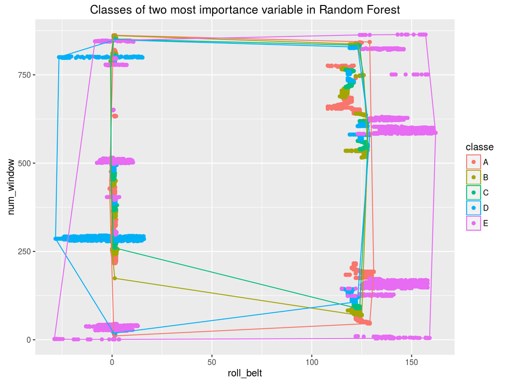

```r
p2 <- ggplot(trn2, aes(roll_belt, num_window, colour = classe)) +
  geom_point() +
  stat_chull(fill = NA) +
  labs(title="Classes of two most importance variable in Random Forest")
p2
```

## Resume

We had builded model that allow us to predict the manner in which participant did the exercise. Power of our predictions is 99%.